# AMP - Analysis of RCTs part 1 (of 2)

Comparing the two left-most models (which both have y=TotalCredit) shows a very clear difference in quality:

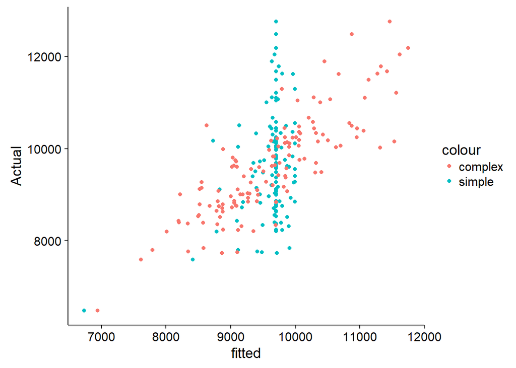

```r
x1 = predict(creditreg)
x2 = predict(creditreg2)
x3= predict(creditreg3)
x4=predict(creditrob)

ggplot() + geom_point(aes(x=x1,y=sdat$TotalCredit, color="simple")) + geom_point(aes(x=x2,y=sdat$TotalCredit, color="complex")) + ylab("Actual") + xlab("fitted")
```

Comparing the two right-most models (y=ln(TotalCredit)) reveals very (very) subtle differences (note the largest shifts are on points furthest from the central mass):

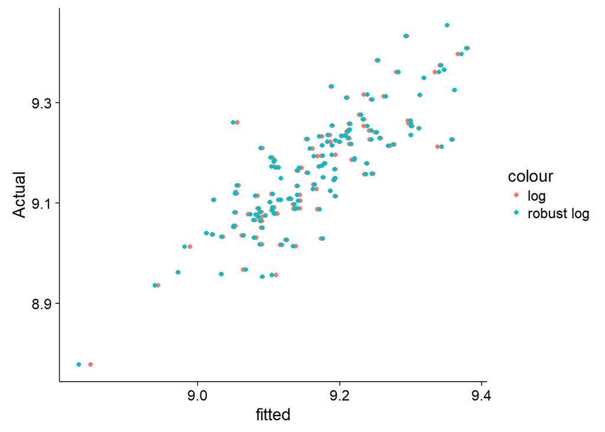

```r
ggplot() + geom_point(aes(x=x3,y=sdat$logCredit, color="log")) + geom_point(aes(x=x4,y=sdat$logCredit, color="robust log")) + ylab("Actual") + xlab("fitted")
```

Finally, let’s compare our complex TotalCredit model with our complex log(Total Credit model) (i..e models 2 and 3), to do this we will exponent the fitted values produced by model 3:

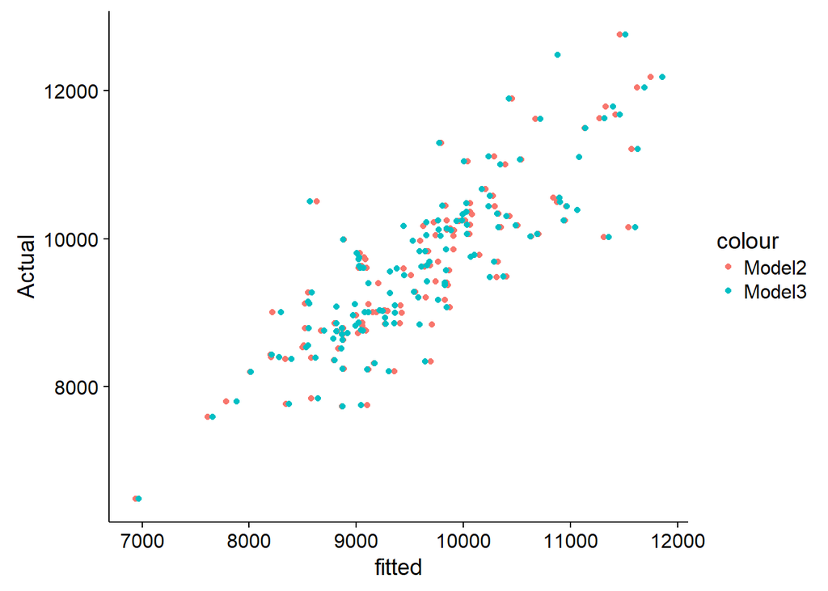

```r
x2 = predict(creditreg2)
x3= exp(predict(creditreg3))


ggplot() + geom_point(aes(x=x2,y=sdat$TotalCredit, color="Model2")) + geom_point(aes(x=x3,y=sdat$TotalCredit, color="Model3")) + ylab("Actual") + xlab("fitted")
```

```r
r2_lin = summary(creditreg2)$r.squared
```

We can see that these models also produce highly similar fits.

Overall, the best model is Model 4 (the robust ln model). However given the similarity of the fits, we could chose to use model 2 (untransformed model) for the improved interpretability. The decision (and justification) is up to the analyst.

We have now seen how to analyse clustered data using the summarization method outlined in [AMP lesson 2](https://michael-bar.github.io/AMP-lessons/AMP-2-RCT-principles.html). The next section will cover the analysis of clustered data at the individual level.

## 6.4 Summary

- Regression is an artful science.
- R-squared, p-value and coefficient aren’t the only regression outputs you should examine! Look at the F-statistics, the diagnostic plots, and the graphs of actual vs fitted to understand what your regression model is doing and where its limitations might be!
- It’s entirely possible to have a good R-squared but a terrible model!
- Interpreting coefficients from transformed y variables isn’t as simple as performing a back-transform!
- Directly compare model statistics side-by-side with the `stargazer` function.
- Compare model additions with the ANOVA test for goodness-of-fit.
- The analyst must make a trade-off between model goodness-of-fit and interpretability. I would expect to see a section in every write up outlining, quantifying and justifying this trade off.

# 7 Regression analysis on clustered data - mixed effect models

In [AMP lesson 2](https://michael-bar.github.io/AMP-lessons/AMP-2-RCT-principles.html) we posited two different solutions to the problem of clustering. The first solution involved summarizing the data so that the unit of analysis and unit of inference match (see above). The second approach involves examining the raw (un-summarized) data itself.

Whilst the overall approach for un-summarized data will be similar to that of summarized data, there is one key difference which motivates us to use slightly different tools:

**the clustering in our data means that each farmer is no longer a truly independent data point, and consequently our error estimates will be mis-specified** .

As these error estimates are subsequently used in hypothesis testing, incorrect errors can lead to in-accurate p-values and false significance.

## 7.1 Enter the mixed effect model

To correct the effect of clustering on our errors, we will introduce some new terms into our linear equation. Two key concepts going forward will be:

- Fixed effects: cluster-invariant effects - think of these as effects constant across individuals
- Random effects: cluster-variant effects - think of this as compensating for the non-independence in clustered data. Random effects can include data measured at the individual level but randomized at a higher level (as here), but can also include repeated measurements from a single individual (think time-series data, or measuring the strength of someone’s left *and* right hands).

The key insight here is that in a linear model we had a fairly boring term $e$:

- $Y = C + \beta . X + e$

Which represented our error, and which we believed to be normally and independently (think randomly) distributed. In mixed modelling we will make our $e$ term slightly more interesting as we are expecting it to correlate with cluster. In doing this we will allow our mixed model to fit a separate intercept for each site (whilst ensuring that the coefficients are the same). This is analogous to saying that whilst the intercept can differ, the overall *rate of change* is the same across sites. It *is* possible to also allow the coefficient to vary by site, but we will not cover that here.

So note that our original linear model above becomes slightly more interesting:

- $Y_{nj}= C + \beta . X + U_n + W_{nj} + e$

We’ve now introduced terms to account for cluster-specific effects ($U_n$) and individual-within-cluster effects ($W_{nj}$) to yield our estimate for the individual-within-cluster response $Y_{nj}$. Note that $\beta . X$ is our unchanged fixed-effect, and $e$ is still our i.i.d. error term. (This will hopefully become clearer when we look at some model outputs below.)

In a mixed model, we will retain many of the assumptions of linear modelling, e.g.:

- Normal residuals
- uncorrelated predictor variables
- linear relationships

and add the assumption that:

- random-effects are also normally distributed

The rest of this lesson will examine how to use and diagnose mixed models, first with some simple simulated data, and then with our NCM data at the farmer level.

In summary, the mixed effect model will essentially fit a series of parallel lines with different intercept terms across our data. We will use this distribution of lines to calculate a more accurate standard error of the mean which will yield more accurate p-values.

## 7.2 Summary

- Mixed effects models rely on your understanding of the experiment set-up to identify random effects
- Mixed effects operate under similar assumptions to linear regressions, with the added assumptions around random-effects
- In a mixed model we retain our i.i.d. $e$ error, and gain terms for between cluster variation
- Mixed models will also be used in cases where measurements of a single individual are repeated

# 8 Theory: Understanding mixed modelling through simulation

Let’s demonstrate how these concepts work and how we can examine the assumptions with some simulation data before proceeding to the more complex NCM data.

```r
set.seed(123)
library(knitr)

indivs <- 12 #aka J
clusters <- 75 #aka N

tdf <- data.frame( Cluster = sort(rep(c(1:clusters),indivs)),        Indiv = rep(c(1:indivs),clusters) , x = rnorm(n = indivs*clusters,0,5) )

#we now have X

# lets get intercept diff
inte <- rnorm(clusters,0,50)
ntdf = c()
intey = 25 + inte

#assign distinct beta to each cluster
for(i in seq(1:length(unique(tdf$Cluster))) ) {

  cc = unique(tdf$Cluster)[i]
  val = inte[i]
  #print(paste(i,cc,val))

  tx = subset(tdf, Cluster==cc)
  tx$inte = val

  ntdf = rbind(tx,ntdf)


}

library(knitr)

#we now have beta shared within clusters but not between


#make Y

# y = intercept + x * beta + iid noise
ntdf$y <- 25 + ntdf$inte + (ntdf$x * rnorm(clusters*indivs,3,0.5)) + rnorm(clusters*indivs,0,15)
kable(rbind(head(ntdf,3),tail(ntdf,3)), row.names = FALSE)
```

| Cluster | Indiv | x | inte | y |
| --- | --- | --- | --- | --- |
| 75 | 1 | -3.823030 | 49.30291 | 80.8144479 |
| 75 | 2 | 1.976479 | 49.30291 | 115.6467368 |
| 75 | 3 | -4.952538 | 49.30291 | 29.7727725 |
| 1 | 10 | -2.228310 | -50.70571 | -32.2330721 |
| 1 | 11 | 6.120409 | -50.70571 | 0.6225679 |
| 1 | 12 | 1.799069 | -50.70571 | -25.8276100 |

```r
d = ntdf
```

In the data.frame above we can see that we have a number of individuals grouped by cluster. Each individual has a unique X (normally distributed) and a beta (normally distributed), as well as a cluster-level intercept term which will result in normal deviations from the intercept. Our aim is to recover our *real* intercept (and other values):

To model random and fixed effects together we will use the `lme` function from package `nlme`, which requires the following arguments:

Additional arguments include:

- `weights`: this argument can be used to specify heteroskedastic errors (not covered here)
- `method`: the method to find a solution, we will use maximum likelihood (`"ML"`)
- `na.action` - what should be done with any NAs in the data (set to `na.exclude`)

So for our simulation above, our R code will be:

- `lme(fixed=y~ x ,data=d, random=~1|Cluster,na.action=na.exclude,method="ML")`

```r
library(nlme)

mixmo <- lme(fixed=y~ x ,data=d, random=~1|Cluster,na.action=na.exclude,method="ML")




#stargazer(mixmo, type = "html", title="Simple mixed model",notes="",  omit.table.layout = "na")
summary(mixmo)
```

```
Linear mixed-effects model fit by maximum likelihood
 Data: d
       AIC      BIC    logLik
  7795.572 7814.782 -3893.786

Random effects:
 Formula: ~1 | Cluster
        (Intercept) Residual
StdDev:    53.03307 14.84361

Fixed effects: y ~ x
                Value Std.Error  DF   t-value p-value
(Intercept) 23.629657  6.150534 824  3.841887   1e-04
x            3.185321  0.103734 824 30.706484   0e+00
 Correlation:
  (Intr)
x -0.002

Standardized Within-Group Residuals:
        Min          Q1         Med          Q3         Max
-2.97175154 -0.65712377  0.01927532  0.62663978  3.05934749

Number of Observations: 900
Number of Groups: 75
```

```r
x = 0.5/sqrt(dim(d)[1])
```

We can also use the scoring metrics supplied to evaluate this model against simpler or more complex models:

- [AIC](https://en.wikipedia.org/wiki/Akaike_information_criterion) is a score that trades-off goodness-of-fit vs. model complexity. This makes it a good, simple, tool to compare model quality.
- [BIC](https://en.wikipedia.org/wiki/Bayesian_information_criterion) is closely related to the AIC and used similarly.

Both BIC and AIC are measures of model quality, where a lower value represents a better model. Let’s use AIC scoring now to compare our mixed model with a fixed-effect only model:

```r
fmo <-  gls(y ~ x, method="ML", d)

f1 = AIC(mixmo,fmo)
rownames(f1) <- c("Mixed.model","Fixed.model")
kable(f1)
```

|  | df | AIC |
| --- | --- | --- |
| Mixed.model | 4 | 7795.572 |
| Fixed.model | 3 | 9774.385 |

We can see that the AIC score for our mixed model is substantially lower than our fixed model, with only a single extra degree of freedom. This suggests we are warranted in adding random effects to our model.

We can run an ANOVA (using `anova.lme` from `nlme`) to directly test whether the improved AIC is significant for our new model:

```r
#formatting for prettiness
an <- anova.lme(fmo,mixmo)
row.names( an ) <- c("Fixed model","Mixed model")
an$call = NULL
options(knitr.kable.NA = '')
an$`p-value` = format(an$`p-value`, scientific=TRUE, na.encode=TRUE)
an$`p-value`[1] <- NA
kable(an, caption = "Comparison of models", digits=c(0,0,0,0,0))
```

Comparison of models

|  | Model | df | AIC | BIC | logLik | Test | L.Ratio | p-value |
| --- | --- | --- | --- | --- | --- | --- | --- | --- |
| Fixed model | 1 | 3 | 9774 | 9789 | -4884 |  |  |  |
| Mixed model | 2 | 4 | 7796 | 7815 | -3894 | 1 vs 2 | 1981 | 0e+00 |

The small p-value indicates that the improvement in AIC is indeed significant (note that the p-value corresponds to the “test” column).

Let’s now take a closer look at the outputs from mixed-models and fixed-models to understand the implications of using an incorrect modeling approach:

```r
library(knitr)
tab <- data.frame("Model" = c("Fixed","Mixed"), "Intercept"=c(coef(summary(fmo))[1],coef(summary(mixmo))[1]),"Intercept error"=c(coef(summary(fmo))[3],coef(summary(mixmo))[3]), "X"=c(coef(summary(fmo))[2],coef(summary(mixmo))[2]), "X error"=c(coef(summary(fmo))[4], coef(summary(mixmo))[4]))

kable(tab, digits=2)
```

| Model | Intercept | Intercept.error | X | X.error |
| --- | --- | --- | --- | --- |
| Fixed | 23.59 | 1.84 | 3.60 | 0.37 |
| Mixed | 23.63 | 6.15 | 3.19 | 0.10 |

This table makes it clear that, had we used a simple linear model, we would have under-estimated our error term 3 fold ! Additionally, note:

- Our $\beta$ coefficient for X is mostly unchanged between models, this is expected as we defined that our clusters would differ at the intercept term (not the $\beta$ term).
- Our intercept error is hugely underestimated by a simple linear model, this would have knock-on implications for our p-value testing, and thus our recommendations.

Now we understand the mixed-model outputs, let’s turn to evaluating the quality of our model (vs. the assumptions outlined at the start of this section).

## 8.1 Mixed models; diagnostics

There is no equivalent function in R that will plot a variety of graphs for model interrogation, instead, I have included my own function `plot_lme` which will automatically plot diagnostics from the model. `plot_lme` takes a few arguments:

- `fob`: the lme object
- `realdata`: a vector of real data (i.e. the real Y)
- `df`: the dataframe used
- `namey`: the names of any predictor variables included in the equation.

```r
# load lib
library(nlme)


# a function to plot some lme diagnostics.
plot_lme = function(fob,realdata,df, namey){


  stdr = residuals(fob)/ sd(residuals(fob))
  sqres = sqrt(stdr**2)

  par(mfrow=c(2,3))

  qqnorm(stdr, ylab='Standardized residuals', main="residuals QQplot")
  qqline(stdr)

  # fitted vs actuals

  ran = ranef(fob)

#plot(fitted(fob), realdata, main="fitted vs actual",xlab="Fitted",ylab="actual")
  plot(ran$`(Intercept)`, seq(1:length(ran$`(Intercept)`)), main="random effects", ylab="Site number", xlab="Random effect")
  plot
# fitted vs resid
  plot(fitted(fob), stdr,  main="fitted vs residuals",xlab="Fitted",ylab="standardized residuals")

# estimate leverage
  ma = as.matrix(df[,c(namey)])
  #ma = as.matrix(dat[,c('TotalEnrolledSeasons', 'Maize.adoption','Maize.acres')])
  #rm(hatty)
  # want X * (Xt * X)^-1 * X
  hatty = ma %*% solve(t(ma) %*% ma) %*% t(ma)
  #plot leverage against std.resid.
  plot(diag(hatty), stdr, main="Leverage-residuals",xlab="est.Leverage",ylab="residuals")

  res_lme=residuals(fob)
  plot(res_lme, main="Residuals vs index", ylab="resid")
  abline(a=0,b=0, lwd=4, col="red")


  qqnorm(ranef(fob)$`(Intercept)` , main="Random effects QQplot")
  qqline(ranef(fob)$`(Intercept)` )

}
```

plot_lme will then produce the following graphs:

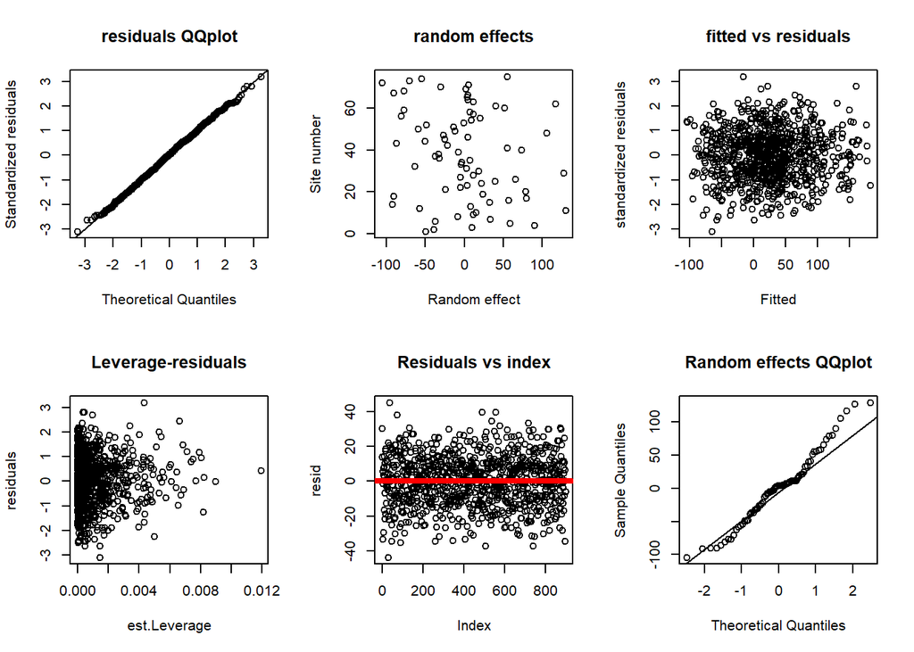

```r
plot_lme(mixmo, d$y, d, c("x"))
```

From top-left to bottom right:

- QQplot of residuals: This should be interpreted as in a linear model
- Scatter plot of random effects: This is a plot of the random effects vs cluster ID. We are hoping to see a random scatter of data points indicating that the random effects are independently distributed
- fitted vs residuals: This should be interpreted as in a linear model
- (estimated) Leverage vs residuals: This should be interpreted as in a linear model
- residuals vs index: This should be interpreted as in a linear model
- QQplot random effects: This plot should be used to determine if the random effects are normally distributed, in conjunction with the random-effects plot.

Finally we can plot the fitted vs actual values for our mixed model and our LM model:

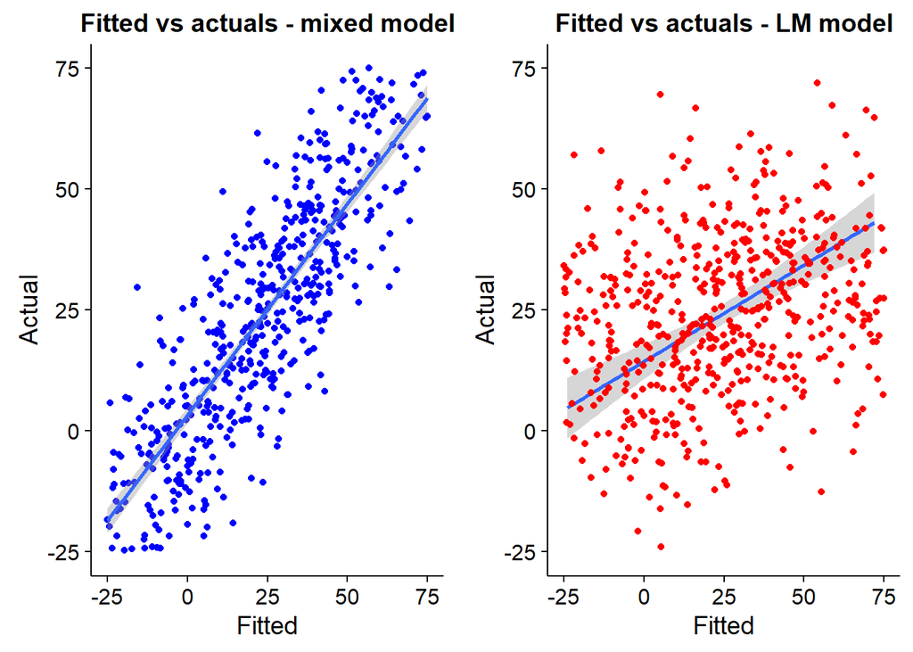

```r
d$fitt = fitted(mixmo)
d$fmol = fmo$fitted
g1 = ggplot(d) +geom_point(aes(x=fitt, y=d$y), color="blue") + xlab("Fitted") + ylab("Actual") + ggtitle("Fitted vs actuals - mixed model")  + xlim(-25,75) + ylim(-25,75) + geom_smooth(aes(x=fitt,y=d$y),method="lm")

g2 = ggplot(d) +  xlab("Fitted") + ylab("Actual") + ggtitle("Fitted vs actuals - LM model")  + xlim(-25,75) + ylim(-25,75) + geom_smooth(aes(x=fmol,y=d$y),method="lm") + geom_point(aes(y=fmol, x=d$y),color="red")

#g3 =  ggplot(d) +  xlab("Fitted") + ylab("Actual") + ggtitle("Fitted vs actuals - LM model")  + xlim(-25,75) + ylim(-25,75) + geom_smooth(aes(x=fmol,y=d$y),method="lm") + geom_point(aes(y=film, x=d$y),color="red")

multiplot(g1,g2,cols=2)
```

This looks great, the mixed-model performs well at predicting all values of Y. Clearly our mixed model has done a good job of separating our fixed and random effects!

This is a very simple example of a mixed model where only our intercept is random, and where there is no relationship between our intercept and slope. Real data will often be less forgiving!

### 8.1.1 Summary

- Mixed effect models contain both random and fixed effects
- In this context, random effects refers to the result of randomizing at the cluster level but measuring at an individual level
- Similar techniques are also applicable to data where multiple readings are taken from single subjects (this will be covered in the upcoming AMP FAQ)
- We can specify random slopes, or intercepts, or both. We can F-test models to understand which additions satisfy the trade-off between goodness-of-fit and complexity.
- As well as the diagnostic plots we saw in `lm` modelling, we additionally need to check the distribution of random effects from `lme`.
- You can see some more advanced simulations [here](http://anythingbutrbitrary.blogspot.co.ke/2012/10/hierarchical-linear-models-and-lmer.html).

# 9 Practical: mixed effect modelling NCM

We now have a much more complicated data set to model, the non-compulsory maize trial results. Remember, that these were collected at the farmer level but randomization occurred at the Site level.

Let’s recall what our un-summarized NCM data looks like:

```r
str(dat)
```

```
'data.frame':   22396 obs. of  13 variables:
 $ OAFID               : int  43141 42509 44278 44284 44280 44283 44282 44271 44268 44272 ...
 $ solar               : num  0 1 1 1 1 1 1 1 0 1 ...
 $ GroupName           : Factor w/ 2290 levels "Abalibayo","Abeingo",..: 1484 2032 1583 1583 1583 1583 1583 1484 1484 1484 ...
 $ X..Repaid           : num  27.1 3.5 49.3 27.9 16.8 26.1 20.4 19.4 26.1 10.8 ...
 $ TotalEnrolledSeasons: int  2 2 1 1 1 1 1 1 1 1 ...
 $ NewMember           : Factor w/ 2 levels "False","True": 1 1 2 2 2 2 2 2 2 2 ...
 $ Treatment           : Factor w/ 2 levels "C","T": 2 2 2 2 2 2 2 2 2 2 ...
 $ DistrictName        : Factor w/ 4 levels "Kabondo","Kakamega (South)",..: 1 1 1 1 1 1 1 1 1 1 ...
 $ SiteName            : Factor w/ 133 levels "Achuth","Ainapngetuny",..: 3 3 3 3 3 3 3 3 3 3 ...
 $ Maize.acres         : num  0.25 0.5 0.25 0.25 0.25 0.25 0.25 0.25 0.25 0.25 ...
 $ Cookstove.qty       : int  1 0 0 0 0 0 0 0 0 1 ...
 $ Maize.adoption      : int  1 1 1 1 1 1 1 1 1 1 ...
 $ TotalCredit         : int  7520 14065 8775 10215 13795 7870 11260 14895 5920 14650 ...
```

We can see that we have 22396 rows of data, representing one row per farmer. Let’s run an `lme` model, using the same fixed effects as our final `lm` model in the first half of this lesson.

```r
ctrl<-lmeControl(maxIter=400,msMaxIter=400, niterEM=400)
#vf1<-varIdent(form= ~1|DistrictName)
#vf2= varPower(form = ~ TotalEnrolledSeason)
cf<-formula(TotalCredit~  Maize.acres + TotalEnrolledSeasons  + Treatment + DistrictName  + Maize.adoption + solar )

model_lme <- lme(cf,data=dat, random=~1|SiteName,control=ctrl,na.action=na.exclude,method="ML")

small <- lme(formula(TotalCredit~  Maize.acres + TotalEnrolledSeasons  + Treatment + DistrictName   + Maize.adoption ),data=dat, random=~1|SiteName,control=ctrl,na.action=na.exclude,method="ML")



m2 <- aov(TotalCredit~  Maize.acres + TotalEnrolledSeasons + NewMember + Treatment + DistrictName   , data = dat)




# xl = lm(fitted(model_lme) ~dat$Maize.acres)
# plot(dat$Maize.acres,fitted(model_lme) )
# abline(xl)
```

Before we turn to the model outputs, let’s look at our diagnostic plots:

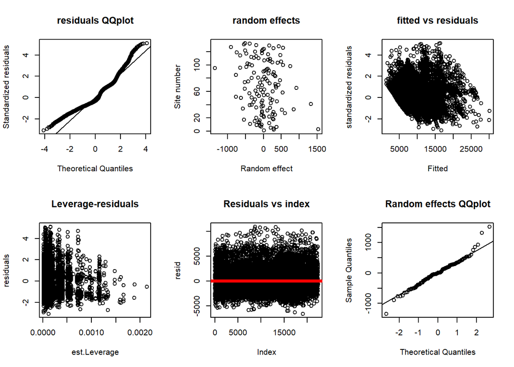

```r
plot_lme(model_lme, dat$TotalCredit, dat, c('TotalEnrolledSeasons', 'Maize.adoption','Maize.acres'))
```

```r
# library(zoo)
# ggplot() + geom_line(aes(y=rollmean(fitted(model_lme)-dat$TotalCredit,100), x= seq(1:length(rollmean(fitted(model_lme)-dat$TotalCredit,100)))) )
# plot(rollmean(fitted(model_lme)-dat$TotalCredit,100))
```

The `random effects QQplot` shows that our random effects are approximately normally distributed (with a few notable outliers). However, the most concerning plots here are the `residuals QQplot` and the `fitted vs residuals` plot, both of which show that our model residuals are non-normal. Let’s examine this in more depth with a `fitted vs actuals` plot:

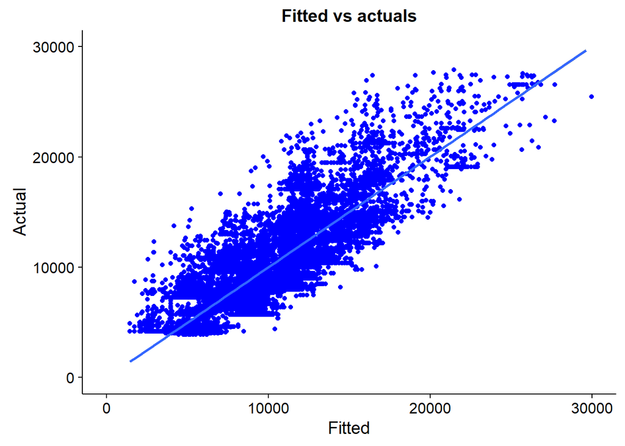

```r
d = data.frame(fitt=as.numeric(fitted(model_lme)) , y=as.numeric(dat$TotalCredit))




ggplot(d) +geom_point(aes(x=fitt, y=d$y), color="blue")+ xlab("Fitted") + ylab("Actual") + ggtitle("Fitted vs actuals") + geom_smooth(aes(x=fitt,y=d$y),method="lm") +xlim(0,30000) + ylim(0,30000)
```

```r
xl = lm(fitted(model_lme) ~dat$TotalCredit)
r2_mixmo = summary(xl)$r.squared
```

The plot above represents a quick summary of our model performance. Note that the regression line appears to be off center from the mass of points. Let’s try looking at this another way for clarity:

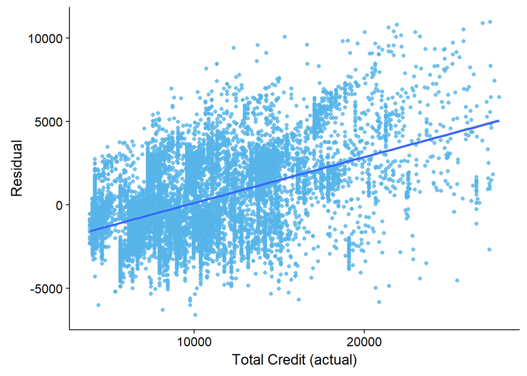

```r
d$resi = (d$y-d$fitt)

ggplot(d) + geom_point(aes(x=y,y=resi), color="#56B4E9", alpha=0.8) + ylab("Residual") + xlab("Total Credit (actual)") + geom_smooth(aes(x=y,y=resi),method="lm", se=TRUE, n=100)
```

This plot shows some important issues with our model:

- Our model is biased towards lower Total Credit values (where there are more points, and where minimization of residuals is more effective)
- There is some heteroskedascity in our model, however this is mostly generated by the model *under-estimating higher TotalCredit values*.

This suggests our model is performing poorly at medium and high TotalCredit values (this, in essence, is also what our diagnostics above show). Note that simply examining the r-squared of the model (0.726) would be misleading. It is possible to have a good r-squared but a terrible model.

Let’s use some creative plotting to show these trends with more clarity. To do this, we will plot another “fitted vs actual” and “fitted vs residuals” plot, but with summarized data to make the graphs easier to read. The code below will plot the average fitted values for each actual TotalCredit value:

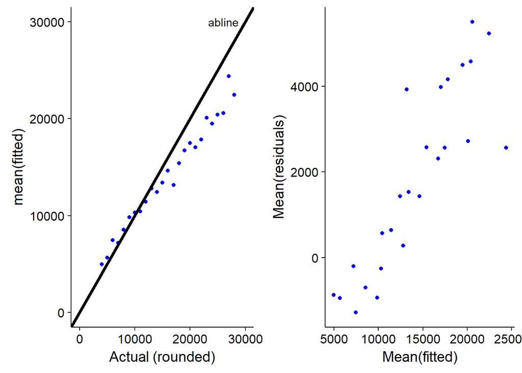

```r
library(zoo)
new = data.frame("actual"=round(dat$TotalCredit,-3), "fitted"=as.numeric(fitted(model_lme)) )

new$diff = dat$TotalCredit - as.numeric(fitted(model_lme))
xm = new %>%
   group_by(actual) %>%
   summarise(yy=mean(fitted), ydiff=mean(diff), ylen=length(fitted))

xm$ylen = (xm$ylen / sum(xm$ylen) )*100


g1 =ggplot() + geom_point(aes(xm$actual, xm$yy),color="blue") + xlab("Actual (rounded)") + ylab("mean(fitted)") + xlim(0,30000) + ylim(0,30000) + geom_abline(size=1.5) + annotate("text", x = 26000, y = 30000, label = "abline")

g2 = ggplot() + geom_point(aes(xm$yy, xm$ydiff),color="blue") + xlab("Mean(fitted)") + ylab("Mean(residuals)")

p<-ggplot(data=xm, aes(x=actual, y=ylen)) +  geom_bar(stat="identity")+ xlab("Actual (rounded)") + ylab("Frequency (%)")


multiplot(g1,g2,cols=2)
```

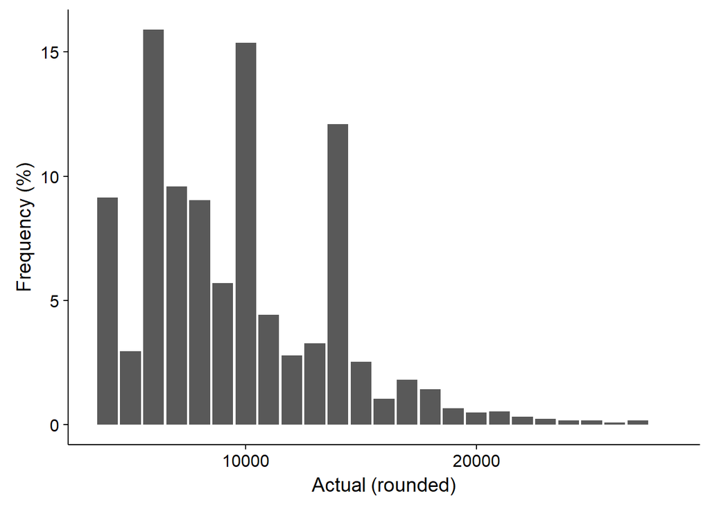

```r
multiplot(p,cols=2)
```

These graphs let’s us see three things easily:

- Our fits for high TotalCredit scores are biased down, leading to under-estimates of high Total Credit values
- Our residuals increase at higher predictions
- We have a much larger mass of data points at low TotalCredit than high TotalCredit

Together, these graphs suggest that we have a large mass of data at low TotalCredit values that is biasing our model, causing it to under-estimate high Total Credit values.

We can see this in the following graph:

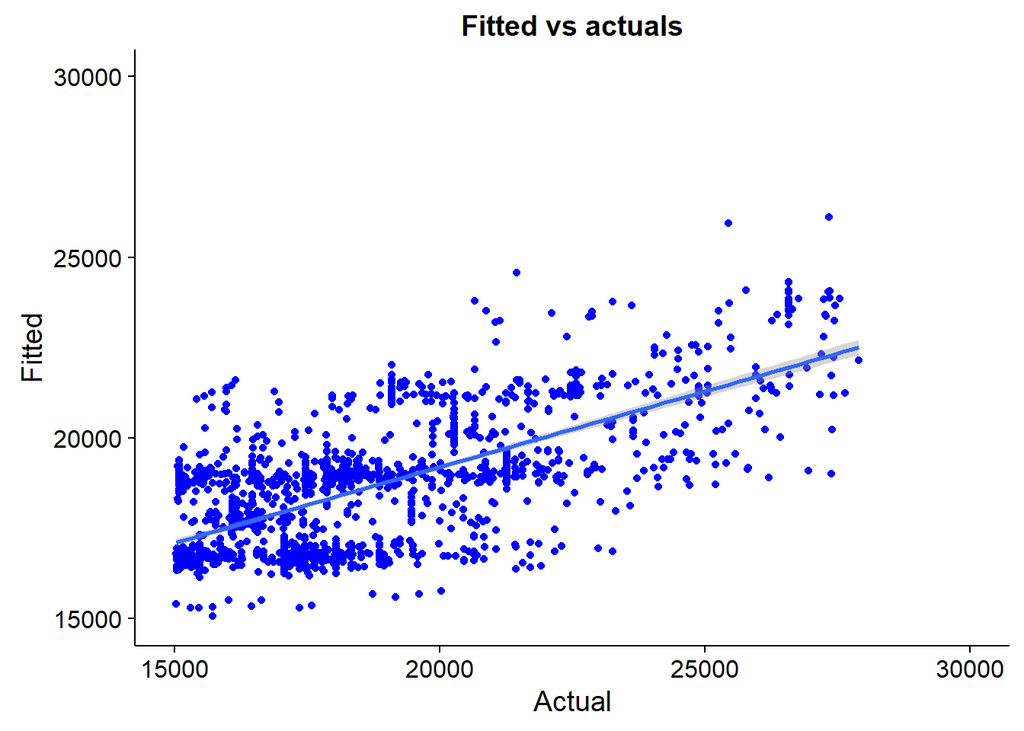

```r
d <- subset(dat, TotalCredit > 15000)

model_lmesub <- lme(cf,data=d, random=~1|SiteName,control=ctrl,na.action=na.exclude,method="ML")


da = data.frame(fitt=as.numeric(fitted(model_lmesub)) , y=as.numeric(d$TotalCredit))




ggplot(da) +geom_point(aes(y=fitt, x=da$y), color="blue")+ ylab("Fitted") + xlab("Actual") + ggtitle("Fitted vs actuals") + geom_smooth(aes(y=fitt,x=da$y),method="lm") +xlim(15000,30000) + ylim(15000,30000)
```

Observe around $y=17000$ and $y=19000$ we see two parallel clusters of points. These clusters remain stubbornly at at $y=17000$ and $y=19000$, whilst our actual TotalCredit varies from (approx) 15,000 to 20,000. I suspect it is these clusters that are causing the behavior examined above.

At this point, we would want to explore any additional variables that might help to further discriminate between farmers with lower TotalCredit values. However, our data set does not include additional data for us to include. Alternatively, we could weigh points with higher TotalCredit more than points with low TotalCredit, this would improve performance at higher TotalCredit values at the expense of lower TotalCredit values (where the majority of our farmer data points actually lie).

Weighting our data isn’t attractive, and we have no additional data to add to our model, therefore we are unable to improve our model any further. We will proceed by instead interpreting our model with the caveats outlined above in mind.

It is worthwhile to note at this point that all models are flawed, but it is important to investigate *exactly* where these flaws are and how they might change your interpretation.

**For our mixed model, it is clearly capable of explaining a large amount of variance in our data, however, it will systematically under-estimate larger TotalCredit values.**

Before we conclude the mixed-modelling portion of the lesson, let us look at one more fundamental question, was the inclusion of random effects statistically warranted, i.e. do we have evidence for group level variation in transaction size?

## 9.1 Evaluating mixed effects

To understand whether the inclusion of random effects is statistically warranted in our model, we will compare the predictions and AIC scores of our mixed model, with a simpler fixed-effect only model.

First, let’s examine the fits of our mixed model and our fixed model (we’ll first plot all the data, and then some random subsets for clarity):

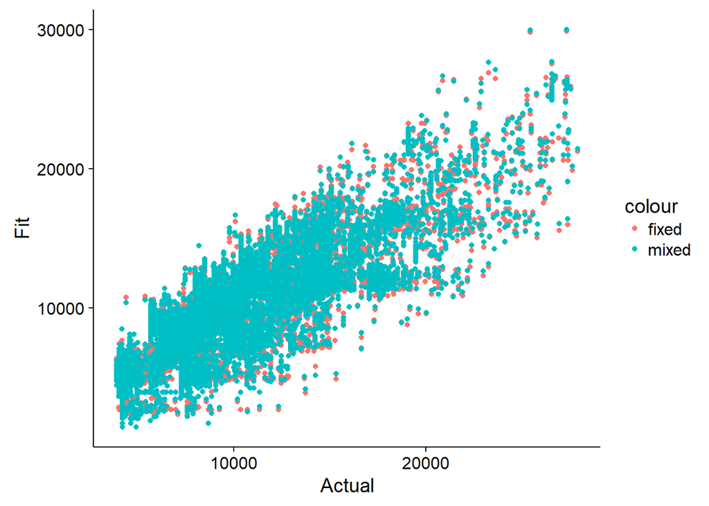

```r
fmod <-  gls(cf, method="ML", dat)



df = data.frame(real=dat$TotalCredit, fix=fitted(fmod), mix=fitted(model_lme))


ggplot(sample_frac(df,1)) + geom_point(aes(x=real,y=fix,colour="fixed")) + geom_point(aes(x=real, y=mix,colour="mixed")) + xlab("Actual") + ylab("Fit")
```

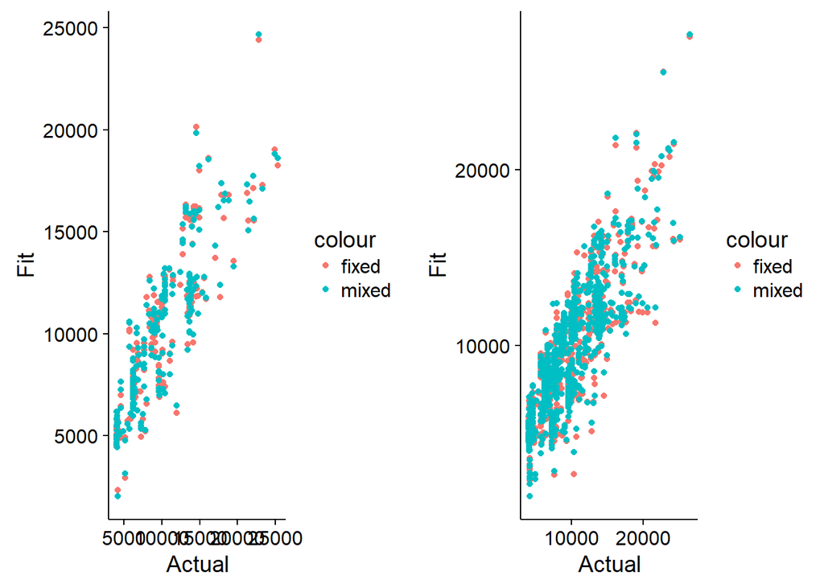

```r
set.seed(111)
g1 = ggplot(sample_frac(df,0.01)) + geom_point(aes(x=real,y=fix,colour="fixed")) + geom_point(aes(x=real, y=mix,colour="mixed")) + xlab("Actual") + ylab("Fit")

set.seed(222)
g2 = ggplot(sample_frac(df,0.05)) + geom_point(aes(x=real,y=fix,colour="fixed")) + geom_point(aes(x=real, y=mix,colour="mixed")) + xlab("Actual") + ylab("Fit")

multiplot(g1,g2,cols=2)
```

Hmm, it looks like there are some differences in fit quality. Let’s test model AICs with an ANOVA:

```r
an2 = anova.lme(fmod,model_lme)


row.names( an2 ) <- c("Fixed model","Mixed model")
an2$call = NULL
options(knitr.kable.NA = '')
#an2$`p-value` = format(an$`p-value`, scientific=TRUE, na.encode=TRUE)
#an2$`p-value`[1] <- NA
kable(an2, caption = "Comparison of models", digits=c(0,0,0,0,0))
```

Comparison of models

|  | Model | df | AIC | BIC | logLik | Test | L.Ratio | p-value |
| --- | --- | --- | --- | --- | --- | --- | --- | --- |
| Fixed model | 1 | 10 | 408062 | 408142 | -204021 |  |  |  |
| Mixed model | 2 | 11 | 407515 | 407603 | -203746 | 1 vs 2 | 549 | 0 |

We see a significant decrease in AIC with our mixed model (and this is statistically significant at the p<0.05 level). This is a good indicator that we do indeed see random level effects (in this context, it means have evidence for Site level deviations from the population mean). Our model output suggests that random effects explain ~400 KES of the variation in our data (this information can be accessed via the `summary()` command, as `stargazer` doesn’t support random effect reporting).

NB. *Please note that AIC scoring should not be minimized at all costs, but rather, as with our LM model choice, should be weighed against other model parameters.*

Overall then, we can say that our model does a reasonable job at explaining TotalCredit variance, that adding random effects is warranted. But that our model will tend to underestimate higher TotalCredit values. Let’s now look at our model summary:

```r
stargazer(model_lme, type = "html",style="all", title="Mixed model regression")
```

**Mixed model regression**

|  | *Dependent variable:* |
| --- | --- |
|  | TotalCredit |
| Maize.acres | 9,452.531*** |
|  | (54.362) |
|  | t = 173.880 |
|  | p = 0.000 |
| TotalEnrolledSeasons | 360.691*** |
|  | (11.158) |
|  | t = 32.326 |
|  | p = 0.000 |
| TreatmentT | 80.684 |
|  | (81.150) |
|  | t = 0.994 |
|  | p = 0.322 |
| DistrictNameKakamega (South) | -609.307*** |
|  | (107.360) |
|  | t = -5.675 |
|  | p = 0.00000 |
| DistrictNameMigori | 394.658*** |
|  | (109.596) |
|  | t = 3.601 |
|  | p = 0.0005 |
| DistrictNameTinderet | -168.517 |
|  | (142.908) |
|  | t = -1.179 |
|  | p = 0.241 |
| Maize.adoption | -192.767** |
|  | (82.832) |
|  | t = -2.327 |
|  | p = 0.020 |
| solar | 3,721.025*** |
|  | (27.571) |
|  | t = 134.962 |
|  | p = 0.000 |
| Constant | 2,427.642*** |
|  | (117.315) |
|  | t = 20.693 |
|  | p = 0.000 |
| Observations | 22,396 |
| Log Likelihood | -203,746.400 |
| Akaike Inf. Crit. | 407,514.800 |
| Bayesian Inf. Crit. | 407,603.000 |
| *Note:* | p<0.1; p<0.05; p<0.01 |

This model suggests that almost all effects are statistically significant, **except** for treatment! Note the large p-value for treatment status too.

Let’s summaries our mixed-model learnings before the final part of this lesson, model selection.

## 9.2 Mixed effect models Summary

- Mixed effect models are useful when we suspect clustering in our data (either by repeated measurement or group-level effects)
- We can assess our data for clustering either through the ICC method (seen in [AMP lesson 2](https://michael-bar.github.io/AMP-lessons/AMP-2-RCT-principles.html#4302_option_2:_use_the_icc)) or through ANOVA testing fixed and mixed effect models
- We have to check our models for the standard linear model assumptions (normal residuals, etc) as well as for normality of random effects.
- We haven’t dealt with correlated variables in mixed (or fixed) models yet, there is an excellent paper [here](http://www.stat.columbia.edu/~gelman/research/unpublished/Bafumi_Gelman_Midwest06.pdf), which will be dealt with in AMP lesson 6
- There is also a more advanced lesson on mixed models [here](https://ase.tufts.edu/gsc/gradresources/guidetomixedmodelsinr/mixed%20model%20guide.html), for those with better R and mathematical skills.

# 10 Model selection and results interpretation

At the conclusion of this lesson we have three sets of results:

- Our hypothesis tests
- Our summarized model, with an r-squared of 0.705
- Our mixed model, with a (pseudo) r-squared of 0.726

All three of these results suggest that the intervention (non-compulsory maize) had no significant effect on TotalCredit (within the framework of limited power and MDEs discussed above).

However, we might want to understand some of the other factors that affect transaction size (TotalCredit) from our regression models:

```r
#stargazer(model_lme, creditreg2)

stargazer(creditreg2, model_lme, type="html", title="Comparison of models", column.labels = c("Summarised model","Mixed model") , dep.var.labels.include = FALSE, dep.var.caption = "Dependent variable: Total Credit ", digits=2 , omit = c("solar","NewMember"))
```

**Comparison of models**

|  | Dependent variable: Total Credit |  |
| --- | --- | --- |
|  | *OLS* | *linear* |
|  |  | *mixed effects* |
|  | Summarised model | Mixed model |
|  | (1) | (2) |
| Maize.adoption | 92.35 | -192.77** |
|  | (977.58) | (82.83) |
| Maize.acres | 6,082.33*** | 9,452.53*** |
|  | (793.88) | (54.36) |
| TreatmentT | -59.28 | 80.68 |
|  | (121.60) | (81.15) |
| DistrictNameKakamega (South) | -936.62*** | -609.31*** |
|  | (178.24) | (107.36) |
| DistrictNameMigori | 1,009.89*** | 394.66*** |
|  | (159.29) | (109.60) |
| DistrictNameTinderet | 42.45 | -168.52 |
|  | (337.05) | (142.91) |
| TotalEnrolledSeasons | 258.07* | 360.69*** |
|  | (133.00) | (11.16) |
| Constant | 5,849.94*** | 2,427.64*** |
|  | (729.89) | (117.32) |
| Observations | 133 | 22,396 |
| R<sup>2</sup> | 0.70 |  |
| Adjusted R<sup>2</sup> | 0.69 |  |
| Log Likelihood |  | -203,746.40 |
| Akaike Inf. Crit. |  | 407,514.80 |
| Bayesian Inf. Crit. |  | 407,603.00 |
| Residual Std. Error | 610.34 (df = 125) |  |
| F Statistic | 42.60*** (df = 7; 125) |  |
| *Note:* | p<0.1; p<0.05; p<0.01 |  |

We can note from the above that either formulation of the model results in treatment status being non-significant with regards to Total Credit. We can also see broad agreement in the significance in Maize.acres and District (and some agreement in TotalEnrolledSeasons). The most significant disagreement between these models is the effect of Maize.adoption on TotalCredit.

Contrasting the mixed model and summarized model, we can see that the summarized model yields a lower R-squared. However, our summarized model produces healthier diagnostics and does not show signs of bias (vs. our mixed model). When comparing models this graphic comes in handy:

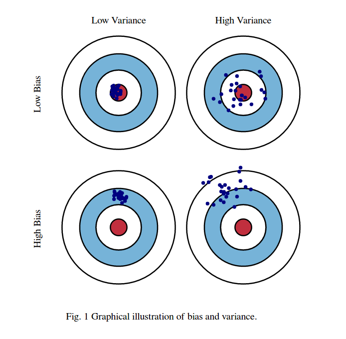

```r
knitr::include_graphics("./var_bias.png")
```

This diagram neatly sums up the common trade-offs we make when selecting models. Take a moment to look at the difference between bias and variance to understand what trade-off we are weighing up between our summarized model and mixed model.

In this case, I would be more willing to trust the results from our summarized model than our mixed-effect model, that is, I would choose a model with higher variance and lower bias.

Note though, that whilst there is a difference of significance between the summarized model and the mixed-effect model, the overall magnitude of the coefficient is very small (~200 KES, or 2 USD). Therefore the *importance* of this finding, one way or another, is minimal, and we can dismiss it as being an *un-important* driver of transaction size (regardless of its p-value).

Overall, the summarized model produces fairer diagnostics and is easily interpretable. Therefore this is our model of choice for this analysis:

```r
stargazer(creditreg2, type="html", title="Model of choice" , dep.var.labels.include = FALSE, dep.var.caption = "Dependent variable: Total Credit ", digits=2 , omit = c("solar","NewMember"))
```

**Model of choice**

|  | Dependent variable: Total Credit |
| --- | --- |
| Maize.adoption | 92.35 |
|  | (977.58) |
| Maize.acres | 6,082.33*** |
|  | (793.88) |
| TreatmentT | -59.28 |
|  | (121.60) |
| DistrictNameKakamega (South) | -936.62*** |
|  | (178.24) |
| DistrictNameMigori | 1,009.89*** |
|  | (159.29) |
| DistrictNameTinderet | 42.45 |
|  | (337.05) |
| TotalEnrolledSeasons | 258.07* |
|  | (133.00) |
| Constant | 5,849.94*** |
|  | (729.89) |
| Observations | 133 |
| R<sup>2</sup> | 0.70 |
| Adjusted R<sup>2</sup> | 0.69 |
| Residual Std. Error | 610.34 (df = 125) |
| F Statistic | 42.60*** (df = 7; 125) |
| *Note:* | p<0.1; p<0.05; p<0.01 |

# 11 Lesson summary

This has been a large lesson, but the key take-homes are:

- Power calculations and MDEs will enable you to understand the limitations of your study, both for hypothesis testing and regression analysis
- Regression assumptions and diagnostics are incredibly important. Remember to check your regression for:
  - Normal residuals
  - Linear relationships
  - Lack of high-leverage points
  - Normal random effects (if they’re included)
- We define a good model as one that can:
  - Explain the full range of variable Y
  - Is unbiased
  - Can produce robust confidence intervals
- Present all relevant materials (diagnostics, justifications) in your reports, you can place these in the appendix.

# 12 Analysis check-list

When conducting an analysis, be sure to check and include the following:

- Check hypotheses are robustly defined
- Check power and MDEs for each key hypothesis
- Hypothesis test each hypothesis with the correct test!
- Check the pre-analysis plan for guidance on whether the analysis is to be carried out by summarization or mixed modelling (most likely, it will be the former)
- Carry out regression analysis, testing assumptions with model-plots as you go
- Keep these tests/plots in an appendix for future readers!
- test model quality through ANOVA testing to ensure model additions are warranted.
- Clearly state any model caveats or limitations in the main body of the text!
- Present any justifications for analysis or model choices (even if it seems obvious) in the appendix.

# 13 Useful links

- [interpreting residual plots](http://docs.statwing.com/interpreting-residual-plots-to-improve-your-regression/#x-unbalanced-header)
- [Detailed overview of hypothesis testing](http://sphweb.bumc.bu.edu/otlt/mph-modules/bs/bs704_hypothesistest-means-proportions/bs704_hypothesistest-means-proportions_print.html)
- [HBR article on regressions, MBA style](https://hbr.org/2015/11/a-refresher-on-regression-analysis)
- [Some specifics on the OLS method for regression, for diehards only!](http://www.stat.columbia.edu/~fwood/Teaching/w4315/Spring2010/lecture_3.pdf)